# Sentiment Analysis for Amazon Phone Reviews

12/16/2018

## Background

- Amazon is a huge marketplace for items
  - School supplies, food, electronics
- Customers leave reviews for items
  - Ratings, comments
- Ratings system for each item
  - 1 to 5 rating

## Goals

- Sentiment Analysis
- Understand the differences between positive and negative sentiments
  - Unique characteristics of reviews?

## Variables

Variables

| variable_names | descriptions |
| --- | --- |
| Product.Name | Name of the Product |
| Brand.Name | Company that created the product |
| Price | Amount of money for the product |
| Rating | Rating a customer gives the product(Out of 5) |
| Reviews | Written comments regarding the product |
| Review.Votes | Number of votes a review gets |

## Data Cleaning/Exploration

- Look at the structure of the data
- Clean out missing data
- Aggregate data for exploration
- Positive and Negative sentiments
- Add word counts
- Filter data for biggest brands

## Correlation Plot

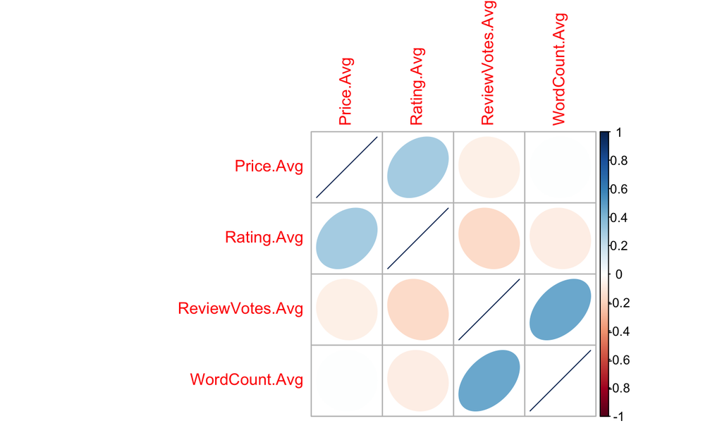

- Ratings/Price are positively correlated
- Word Counts/Review Votes are positive correlated
- Ratings/Review Votes are negatively correlated

## Negative vs. Positive Distribution

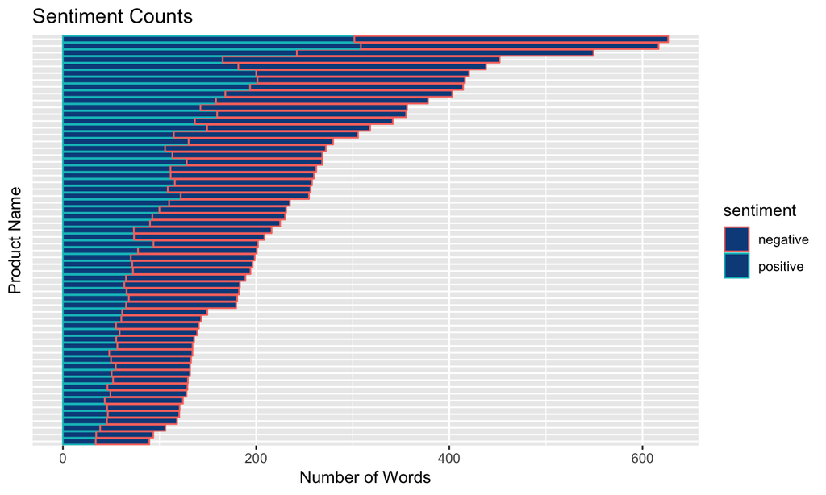

- More words for negative reviews
- Potentially more descriptive

## Pattern Analysis

## Ratings vs. Price

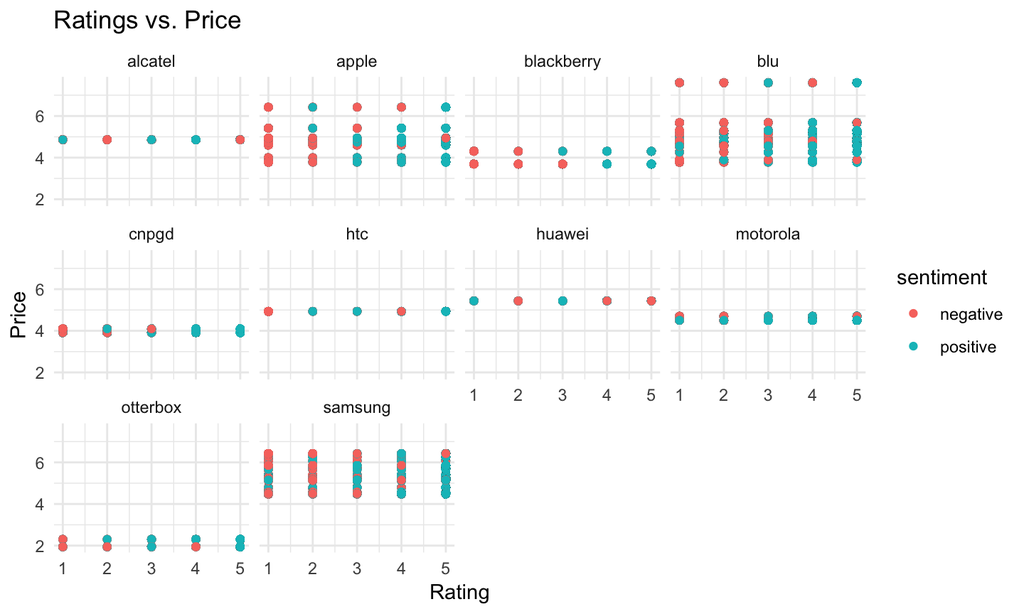

- Negative sentiment = lower rating
- Positive sentiment = higher rating

## Word Count vs. Review Votes

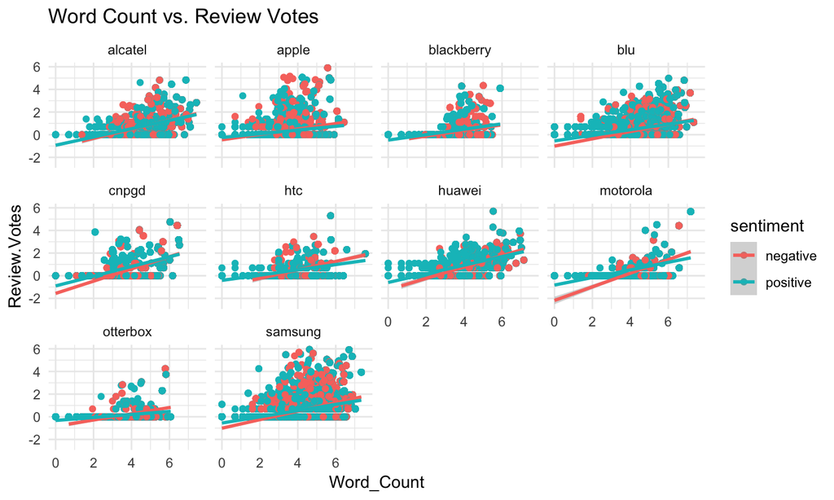

- Upward trend for both positive and negative sentiments
- More words can lead to a higher number of review votes

## Ratings vs. Review Votes

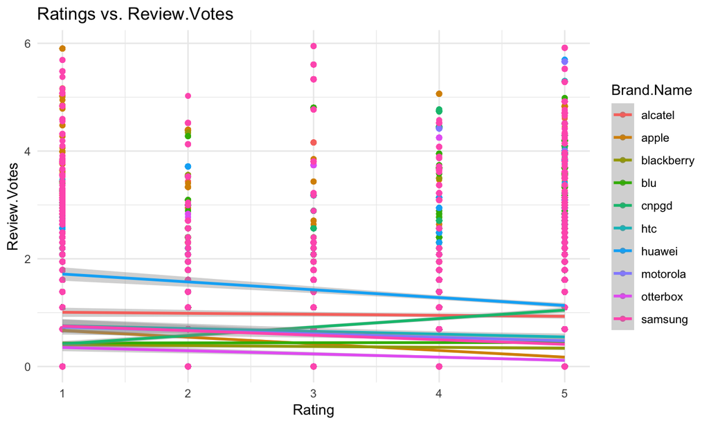

- Increase in ratings means a decrease in review votes
- Inverse relationship
- Reflective of negative correlation

## Distribution of Word Counts

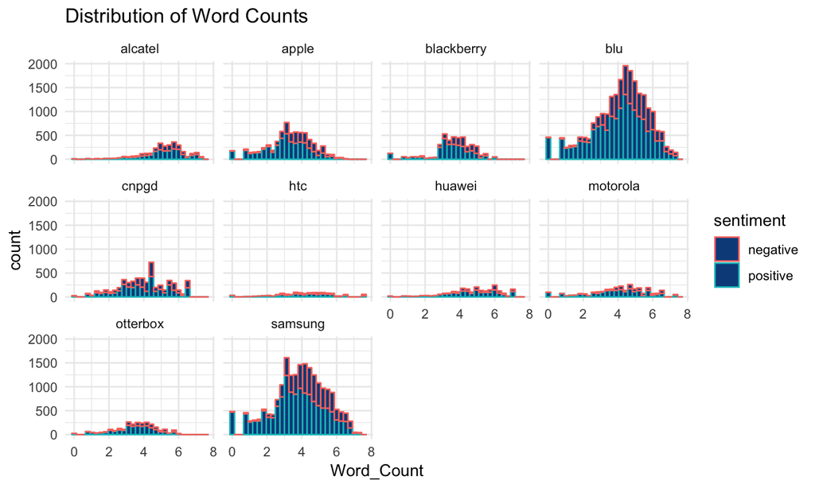

## Review Meanings

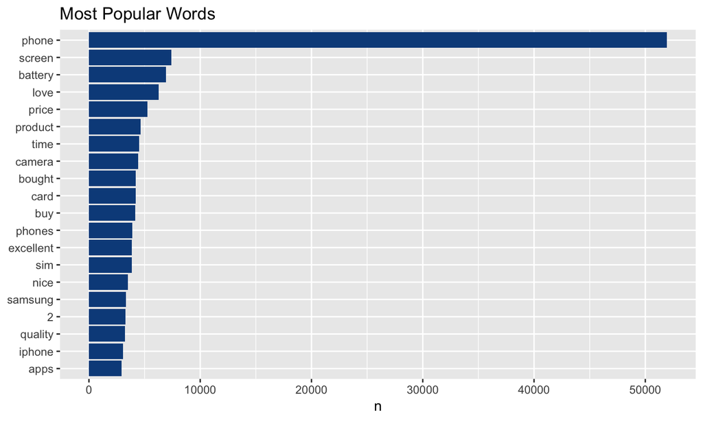

## Review Meanings cont.

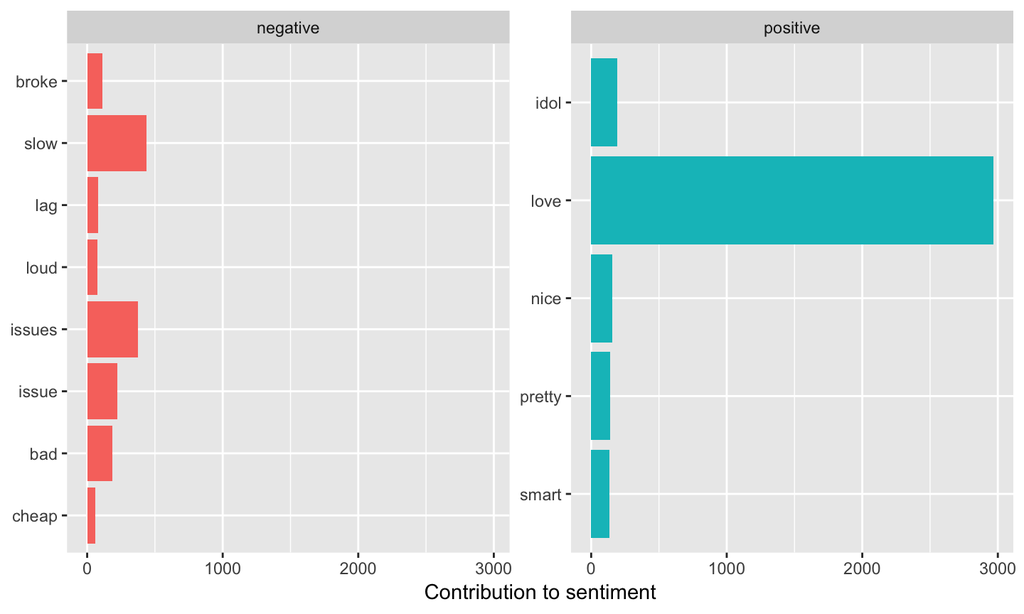

- Positive words are subjective
- Negative words seem to be more feature based and technical
- Negative words get more votes and words

## Benford Analysis

## Benford Analysis for Product Names

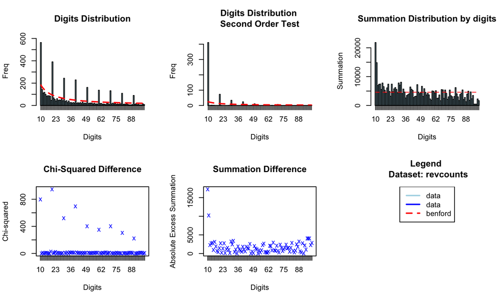

## Benford Analysis for Brand Names

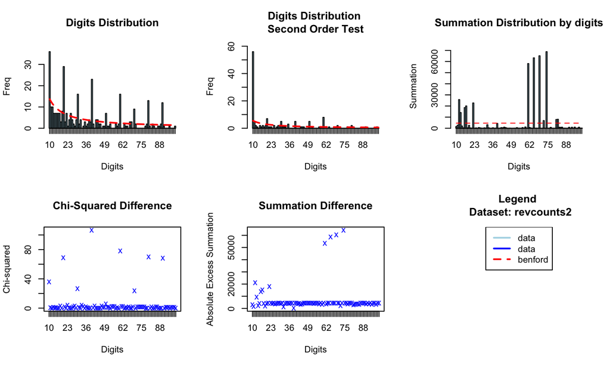

## Conclusion

- Negative reviews had more words than positive reviews
- The more words in a review, the more review votes it had
  - Sincere reviews have more words
- Negative reviews have more words
  - More words = more review votes
  - Negative reviews have more review votes
- Product Names and Brand Name don't follow Benford
  - Fake reviews/"meme" reviews

## Future Works

- In depth sentiment analysis for brands
  - Apple, Samsung
- Creating models based on ratings, prices, number of words, etc